[OHI-Northeast](http://www.ohi-northeast.org/) | [OHI Science](http://ohi-science.org) | [Citation policy](http://ohi-science.org/citation-policy/)

# Wages data layer preparation

Compiled on Wed Apr 29 15:05:02 2020 by afflerbach

## Data Source

### National Ocean Economics Program (NOEP)

**Downloaded**: [Manually downloaded by state from website](http://www.oceaneconomics.org/Market/ocean/oceanEcon.asp) on July 3, 2018.  
**Description**: Total number of jobs and wages per sector for RI, ME, MA, CT, NY and NH counties from 2005 to 2015. The data also include number of establishments and GDP for each sector - state - year.  
**Native data resolution**: County level  
**Time range**: 2005 - 2015  
**Format**: Tabular

**NOTES**:

- The data was cleaned in the `clean_noep_data.R` script.
- All wages are reported in 2012 US Dollars.

## Data cleaning

Read in the cleaned NOEP data.

```r
noep_data = read.csv("data/clean_noep_data.csv")
```

We want to keep the Wages and the Employment data since we are interested in wages per job. I remove the other columns from the NOEP data and filter for “All Ocean Sectors” since this goal is not sector specific.

```r
coast_wages <- noep_data %>%
  select(-X, -Establishments, -GDP) %>%
  filter(Sector == "All Ocean Sectors")
```

## Visualize data

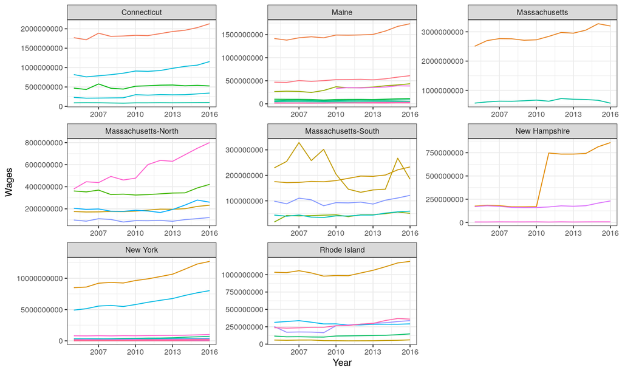

```r
ggplot(coast_wages, aes(x = Year, y = Wages, color = County)) +
  geom_line() +
  theme_bw() +
  facet_wrap(~rgn_name, scales = "free") +
  theme(legend.position = "none")
```

### Meta-analysis

To identify some inconsistencies I see in the data, I’m going to take a look at the reported Wages at both the county level and statewide. One would expect that the sum of the county employment values would equal what is reported for the “Statewide” employment values. It seems that this is not the case.

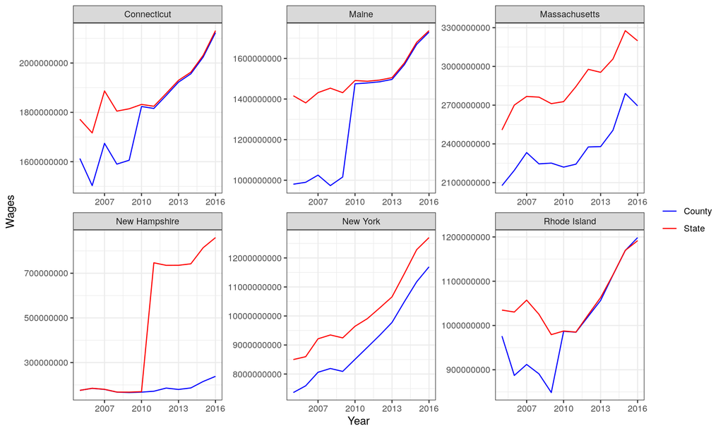

```r
states <-  c("Maine", "New Hampshire", "Rhode Island", "Massachusetts", "Connecticut", "New York")

meta <- function(state){

  all <- coast_wages %>%
    filter(State == !!state,
           str_detect(County, "All")) %>%
    select(Year, Wages) %>%
    distinct() %>%
    rename(all_ctys_wages = Wages)

  out <- coast_wages %>%
    filter(State == !!state,
           str_detect(County, "All") == FALSE) %>%
    select(State, County, Year, Wages) %>%
    distinct() %>%
    group_by(Year) %>%
    summarize(totals = sum(Wages, na.rm = T)) %>%
    left_join(all) %>%
    rename(county_totals = totals,
           statewide = all_ctys_wages) %>%
    gather(key = spatial_res, value = Wages, -Year) %>%
    mutate(State  = !!state)

  return(out)
}

t <- map_df(states, meta) %>%
  distinct()

ggplot(t, aes(x = Year, y = Wages, color = spatial_res)) +
  geom_line() +
  theme_bw() +
  facet_wrap(~State, scales = "free") +
  scale_color_manual(" ", labels = c("County", "State"), values = c("blue", "red"))
```

## Assign spatial scale to use

Using the information gained from the meta analysis above, I’m assigning which spatial scale to use for each of the six states. For Maine, Connecticut, New York, and Rhode Island we are going to use the State level data, which means we filter for rows that say “All [state] counties” and remove the rest. For Massachusetts and New Hampshire we want to keep only the individual county information and then summarize total number of jobs from that data. Finally we join the two datasets and then calculate the **Wages per job**.

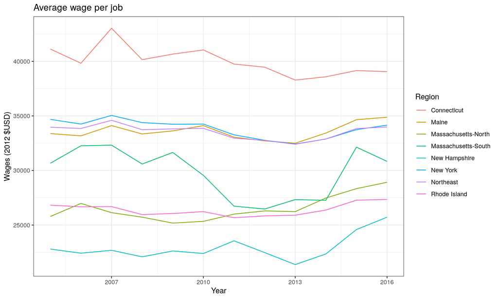

```r
#select the data for ME, CT, NY and RI, which is going to use the data reported for "All x counties"
state_data <- coast_wages %>%
  filter(str_detect(County, "All"),
         State %in% c("Maine", "Connecticut", "Rhode Island", "New York")) %>%
  select(state = State, year = Year, rgn_id, rgn_name, rgn_employment = Employment, rgn_wages = Wages)

#select the data for MA and NH
county_data <- coast_wages %>%
  filter(str_detect(County, "All")== FALSE,
         State %in% c("New Hampshire", "Massachusetts")) %>%
  group_by(rgn_id, Year) %>%
  mutate(rgn_employment = sum(Employment, na.rm = T), #employment by region
         rgn_wages      = sum(Wages, na.rm = T)) %>%  #wagse by region
  select(state = State, year = Year, rgn_id, rgn_name, rgn_employment, rgn_wages) %>%
  distinct()

combo <- bind_rows(state_data, county_data)

#combine to calculate wages across the whole NE region
ne_wages <- combo %>%
  group_by(year) %>%
  summarize(rgn_wages = sum(rgn_wages),
            rgn_employment = sum(rgn_employment)) %>%
  mutate(rgn_id = 12,
         rgn_name = "Northeast",
         state = NA)

wages_data_clean <- bind_rows(combo, ne_wages) %>%
  mutate(wages_per_job = rgn_wages/rgn_employment) %>%
  filter(!is.na(rgn_id))

ggplot(wages_data_clean, aes(x = year, y = wages_per_job, color = rgn_name)) +
  geom_line() +
  theme_bw() +
  labs(x = "Year",
       y = "Wages (2012 $USD)",
       color = "Region",
       title = "Average wage per job")
```

We want to know the wage growth rate over time. We calculate this by comparing the wages per job compared to the average of the previous three years. These regional growth rates will be used to score half of the Livelihoods sub-goal score. I also add in the four offshore regions to the final data layer. The OHI toolbox needs all regions in each data layer. Since this data isn’t relevant offshore, we assign NA values to them.

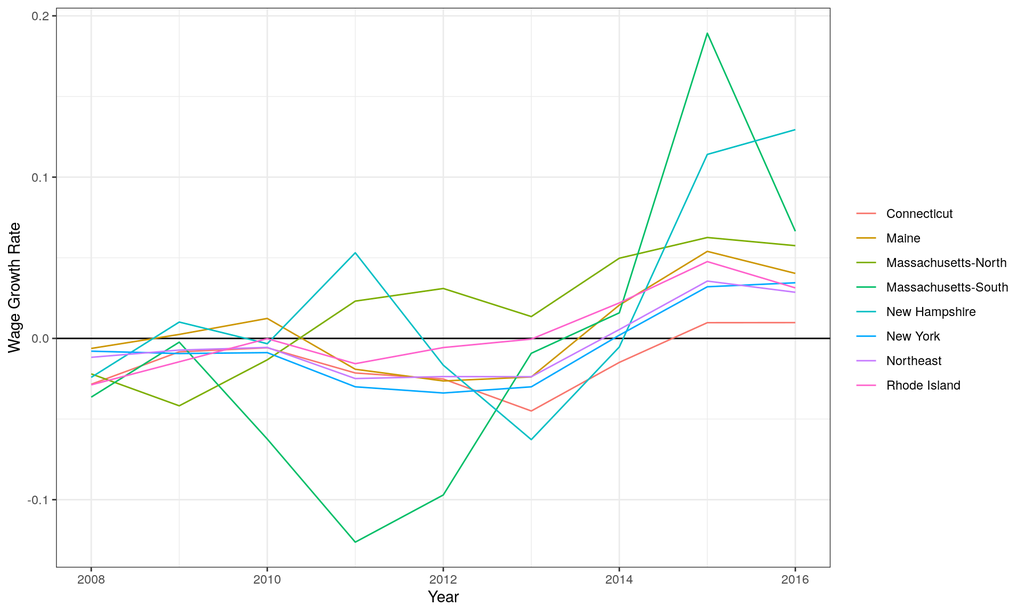

```r
other_rgns <- data.frame(year = rep(2005:2015, each = 4),
                         rgn_id   = c(1,2,3,4),
                         rgn_name = c("Offshore", "Georges Bank", "Gulf of Maine", "Mid-Atlantic Bight"),
                         wage_growth_rate = NA)

wages <- wages_data_clean %>%
  arrange(year) %>%
  group_by(rgn_id) %>%
  mutate(wages_avg_3yr = rollapply(wages_per_job, 3, FUN = mean, align = "right", na.rm = F, partial = T), #calculate the mean for three years
         wages_prev_3yr = lag(wages_avg_3yr, n = 1), #create a new column that aligns the avg wages from previous three years with the year with which we're comparing.
         wage_growth_rate = ifelse(year %in% c(2005:2007), NA, (wages_per_job/wages_prev_3yr)-1)) %>% #assign NA to the first three years in the time series because there is not enough data to calculate this rate. 2007 growth rate *should* be compared to average of 2004-2006.
  write_csv("int/coastal_wage_data.csv") %>%
  select(year, rgn_id, rgn_name, wage_growth_rate) %>%
  ungroup() %>%
  rbind(other_rgns)


write.csv(wages, file.path(dir_calc, "layers/le_coast_wages.csv"))

ggplot(wages %>% filter(!is.na(wage_growth_rate)), aes(x = year, y = wage_growth_rate, color = rgn_name)) +
  geom_hline(yintercept = 0, color = "black") +
  geom_line() +
  theme_bw() +
  labs(y = "Wage Growth Rate",
       x = "Year",
       color = "")
```

## References

National Ocean Economics Program. Ocean Economic Data by Sector & Industry., ONLINE. 2012. Available: http://www.OceanEconomics.org/Market/oceanEcon.asp [3 July 2018]